# SOK-2302 Seminar - Klimaendringer

Author

Andrea Mannberg

# Introduksjon

På dette seminaret vil vi bruke mesteparten av tiden til å simulere effekter av ulike politiske tiltak på klima, miljø og økonomien. Lengre ned i dokumentet finner dere også oppgaver der dere får visualisere klima-relatert data.

## Oppgave 1- En-ROADS

I denne oppgaven skal vi bruke simulator-verktøyet En-ROADS til å utforske effektene av ulike type klima-tiltak. En-ROADS bygger på forskning i både naturvitenskap om effektene av ulike faktorer (f.eks bruk av fossilt brensel) på miljø og klima og samfunnsøkonomi om hvordan økonomien fungerer og effekten av klimaendringene på økonomien.Dere finner en video som forklarer modellen bak en-ROADS [her](https://www.youtube.com/watch?v=pDHwHQ-F_Cg).

Dere finner simulator-verktøyet [her](https://en-roads.climateinteractive.org/scenario.html?v=25.10.0)

### Mål:

Din oppgave er å lage et scenario der oppvarmingen av kloden ikke er høyere enn 2°C.

### Skritt:

1. **Åpne En-ROADS**.Dere vil få en introduksjon til verktøyet på seminaret. Dere kan også lese om kontrollene [her](https://img.climateinteractive.org/2024/09/EnROADS-one-page-guide-v13-Sep2024.pdf).Dere kan også se en introduksjonsvideo [her](https://www.youtube.com/watch?v=4O-5fsVZaII).
2. **Utvikle et scenario**. Bruk En-ROADS til å utvikle et scenario der oppvarmingen ikke er høyere enn 2°C i 2100. Spar scenarioet ved å klikke på “Share your scenario” oppe til høyere og velg “Copy Scenario Link”.
3. Svar på spørsmålene under.

#### Spørsmål:

1. Hvilke var de 3 - 5 viktigste tiltakene i din strategi?
2. Hvilke tiltak og prioriteringer er viktigst for
   - næringslivet,
   - staten, og
   - allmenheten (oss selve) de to kommende årene for å komme på banen til å oppnå målene?
3. Hvilke er de største vinnerne og taperne dersom din plan blir implementert? Lag en tabell med to kolonner for vinnere og tapere.
4. Var det noe som overrasket deg i denne øvelsen (f.eks effekter av ulike tiltak tatt sammen)?
5. Hvilke trender i verden gir deg håp om at dine forslag er mulige?

## Oppgave 2 - Visualisering av temperatur-endringer

I denne oppgaven skal vi se på data knyttet til klimaendringer. Datamaterialet kommer i fra National Oceanic and Atmospheric Administration (NOAA), som er USA:s tilsvarighet til meteorologisk institutt. NOAA har beregnet avvik fra “normalen” (gjenomsnittet i tidsperioden 1970 - 2000) for hvert år og måned i perioden 1850 - 2025. Dere finner datamaterialet [her](https://www.ncei.noaa.gov/data/noaa-global-surface-temperature/v6/access/timeseries/). Dere finner informasjon om innholdet i de ulike filene i ReadMe-filen.

Navnen på datafilene gir informasjon om hva filene innholder. For eksempel innholder filen “aravg.ann.land.00N.30N.v6.0.0.202508.asc” årlig informasjon for avvik i temperaturen over land (landoverflaten) fra ekvatorn (00N) til den 30. breddegraden. Filen inneholder data fram til august i 2025. Filen “aravg.ann.ocean.00N.30N.v6.0.0.202508.asc” har samme informasjon for temperaturen over havet, og “aravg.ann.land_ocean.00N.30N.v6.0.0.202508.asc” inneholder informasjon om totale temperaturavvik (ved overflaten).

Lattituder:

- 90S-90N: Hele jorden
- 00N - 90N: Fra ekvatorn til nordpolen (nordlig hemisfere)
- 90S-00N: Fra sydpolen til ekvatorn (sydlig hemisfere)
- 20S - 20N: Tropikene
- 60N - 90N: Arktis
- 90S - 60S: Antarktis

Når denne oppgaven ble laget, var den amerikanske staten stengt og hjemmesiden ser derfor litt rar ut. Det går likevel å hente data fra siden.

Det er fritt fram å bruke KI til å løse oppgavene, men se til at du har en forståelse for koden som KI lager. Det er ditt ansvar å se til at koden er riktig!

### Oppgave 2.1 - Enkel grafisk illustrasjon av globale temperaturavvik i perioden 1850 - 2025

I denne oppgaven skal vi se på hvordan avviket i temperatur i havet og på land har varierer globalt sett fra år til år.

- Hent data for globale månedlige temperaturavvik for hav og land
- Lag en ny data frame med år, måned, og temperaturavvik
- Beregn gjennomsnittligt måntlig avvik i temperaturen og lag en ny variabel som inneholder denne informasjonen.
- Lag en graf som viser avvik fra normalen (Temperature anomaly) for hvert år i tidsperioden 1850-2025. Y-akselen skal vise avvik, X-akselen skal vise måneder. Bruk en linje-graf der enhvert år har en egen linje.
- Legg in svart, litt tykkere linje som viser gjennomsnittlig avvik fra normalen i perioden.

```r
# Global knitr/quarto options
knitr::opts_chunk$set(message = FALSE, warning = FALSE, echo = TRUE)
library(knitr)
```

```r
library(tidyverse)
library(ggplot2)
library(scales)
```

```r
url <- "https://www.ncei.noaa.gov/data/noaa-global-surface-temperature/v6/access/timeseries/aravg.mon.land_ocean.00N.30N.v6.0.0.202508.asc"
raw_data <- read.table(url, header = FALSE, comment.char = "#")
```

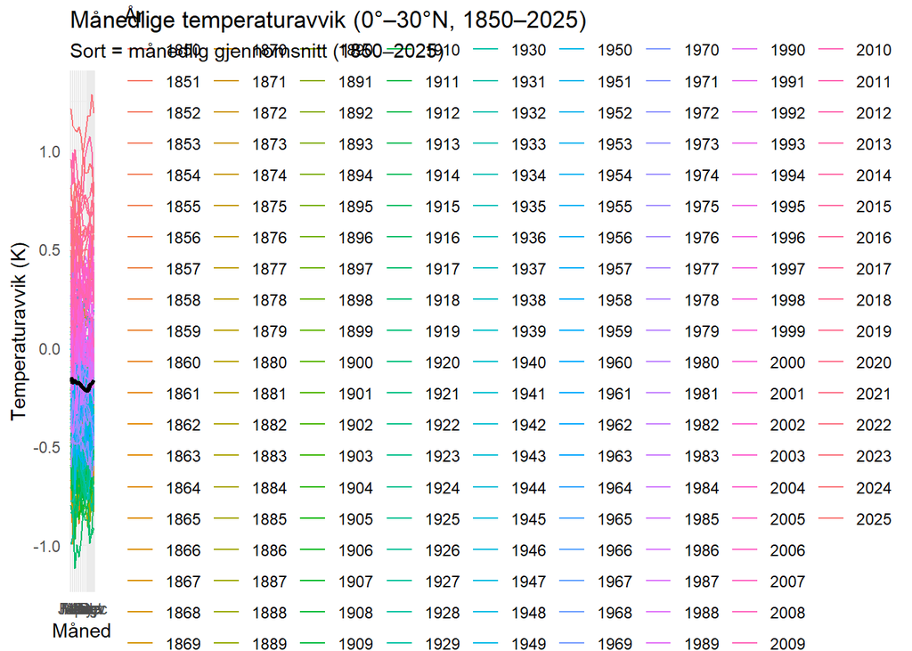

```r
# 2. Behold år, måned, og temperaturavvik
colnames(raw_data)[1:3] <- c("year", "month", "anomaly")
data <- raw_data %>%
  select(year, month, anomaly) %>%
  mutate(year = as.integer(year),
         month = as.integer(month))

# 3. Beregne måntlig gjennomsnittlig avvik fra normalen
monthly_avg <- data %>%
  group_by(month) %>%
  summarise(avg_anomaly = mean(anomaly, na.rm = TRUE))


# 4. En enkel graf
plot1<-ggplot() +
  # All years (thin, grey lines)
  geom_line(data = data, aes(x = month, y = anomaly, group = year, color = factor(year))) +

  # Long-term monthly average (black line)
  geom_line(data = monthly_avg,
            aes(x = month, y = avg_anomaly),
            color = "black", linewidth = 1.2) +

  scale_x_continuous(breaks = 1:12, labels = month.abb) +
  labs(
    title = "Månedlige temperaturavvik (0°–30°N, 1850–2025)",
    subtitle = "Sort = månedlig gjennomsnitt (1850–2025)",
    x = "Måned",
    y = "Temperaturavvik (K)",
    color = "År"
  ) +
  theme_minimal()
print(plot1)
```

- Hvilke konklusjoner kan vi trekke fra denne grafen i henhold til global oppvarming?

Det store antallet år fører til at det er veldig vanskelig å lese ut noe i det hele tatt fra denne grafen.

### Oppgave 2.2 - En litt mer lesbar graf

Som følge av det store tidsrommet er det vanskelig å få et bilde av utvikling over tid i den enkle grafen. I denne oppgaven skal vi derfor prøve å gjøre ting litt mere oversiktlig.

- Lag en graf der alle år fram til og med 2015 har en grå farge og er litt tynnere, mens temperaturavvikene i perioden 2015-2025 har ulike farger. Behold legenden for årene 2015 - 2025, fjern legenden for årene før.

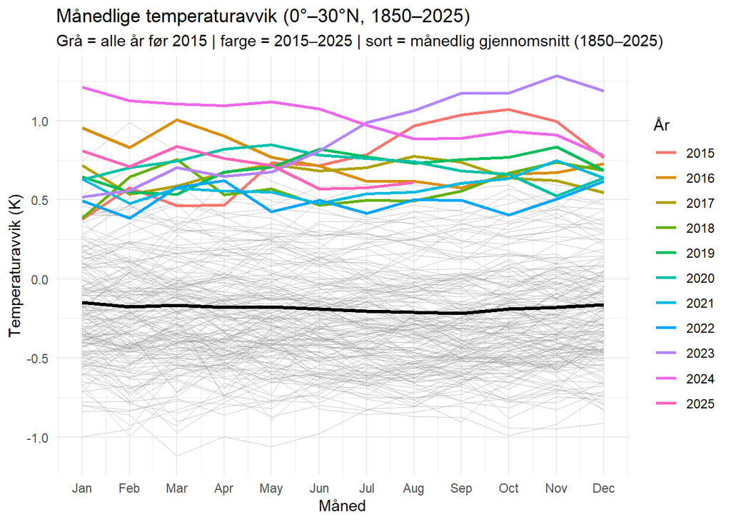

- Hvilke konklusjoner, hvis noen, kan vi trekke fra denne grafen i utviklingen av temperaturen på kloden?

Vi kan se at de siste 10 årene er de med størst positiv temperaturavvik i hele perioden. Dette er en tydelig indikator på at det ikke bare er noen år som er varmere. Det er en trend mot at kloden blir varmere og varmere over tid.

### Oppgave 2.3 - Trender over tid i ulike regioner

I denne oppgaven skal vi se på temperaturavvik i ulike regioner i verden. Med regioner avses her ulike lattitude-bånd på jorden: Hele jorden, nordlige halvkulen, sørlige halvkulen, tropikkene, arktis, og antarktis. For å kunne sammenligne utviklingen i de ulike regionene bruker vi gjennomsnittlige avvik. Mer presist bruker vi et rullende 5-års gjennomsnitt på avvikene. Dataene hentes akkurat som før fra NOAA, men siden vi ønsker å sammenligne ulike regioner må vi bruke flere datafiler. I oppgaven under ser vi på overflate-temperaturen i havet og på land tatt sammen. Du kan selv prøve å endre koden slik at du ser på hav og land separat.

- Kjør koden

```r
# Packer som trengs
library(tidyverse)
library(zoo)    # for å beregne rullende gjennomsnitt
library(lubridate)

# ---- PARAMETRER ----
# Version / date tag i NOAA fil-navn. bytt ut hvis NOAA har nyere filer.
version_tag <- "v6.0.0.202508"

# Variabel som skal brukes (valg av data-fil): "land_ocean", "land", or "ocean"
varname <- "land_ocean"

# Latittude bånd som skal sammenlignes (southLimit.northLimit)
bands <- c(
  "90S.90N",   # Globalt
  "00N.90N",   # Den nordlige halvkule
  "90S.00N",   # Den sørlige halvkule
  "60N.90N",   # Arktis
  "90S.60S",   # Antarktis
  "20S.20N"    # Tropikene
)

# Output
base_url <- "https://www.ncei.noaa.gov/data/noaa-global-surface-temperature/v6/access/timeseries"

# Rullende vindu for smoothing (år)
smooth_yrs <- 5


# ---- FUNKTIONER ----
read_noaa_aravg <- function(band, var = varname, version = version_tag) {
  # Lag filenavn og url
  fname <- sprintf("aravg.mon.%s.%s.%s.asc", var, band, version)
  url <- paste(base_url, fname, sep = "/")

  # les tabell (NOAA ascii: first cols year, month, anomaly, ...; comment lines start with #)
  df <- read.table(url, header = FALSE, comment.char = "#", stringsAsFactors = FALSE)
  colnames(df)[1:3] <- c("year", "month", "anomaly")
  df <- df %>%
    select(year, month, anomaly) %>%
    mutate(year = as.integer(year),
           month = as.integer(month),
           anomaly = as.numeric(anomaly),
           band = band)
  return(df)
}

# ---- LAST INN DATA OG KOMBINER DATAKILDER ----
all_monthly <- map_df(bands, ~ read_noaa_aravg(.x))

# ---- Avvik er i Kelvin (K). Dette er lik °C for forskjeller. Vi behåndler dem som °C ----

# ---- ÅRLIGE GJENNOMSNITT ----
annual <- all_monthly %>%
  group_by(band, year) %>%
  summarise(
    n_months = sum(!is.na(anomaly)),
    annual_anom = ifelse(n_months >= 10, mean(anomaly, na.rm = TRUE), NA_real_),
    .groups = "drop"
  ) %>%
  filter(!is.na(annual_anom))

# ---- BASENIVÅ (1971-2000)  ----
# Månedlig basenivå per måned og region
baseline_monthly <- all_monthly %>%
  filter(year >= 1971, year <= 2000) %>%
  group_by(band, month) %>%
  summarise(clim = mean(anomaly, na.rm = TRUE), .groups = "drop")

# Årlig basenivå (gjennomsnitt av 12 månedlige klimaverdier) per region:
baseline_yr_mean <- baseline_monthly %>%
  group_by(band) %>%
  summarise(baseline_mean = mean(clim, na.rm = TRUE), .groups = "drop")

# Substraher årlig gjennomsnittlig for basenivået (1971-2000) slik at avvikene er eksplisitt relativt til dette basenivået:
annual <- annual %>%
  left_join(baseline_yr_mean, by = "band") %>%
  mutate(annual_anom_clim = annual_anom - baseline_mean) # Dette skal være approksimativt lik orginale anomalier i datamaterialet men sikkerstiller et eksplisitt basenivå

# ---- SMOOTHING (rullende gjennomsnitt) ----
# Konverter til tidsserie og beregne rullende gjennomsnitt (år)
annual <- annual %>%
  arrange(band, year) %>%
  group_by(band) %>%
  mutate(
    roll_n = rollapply(annual_anom_clim, width = smooth_yrs, FUN = mean, align = "center", fill = NA, na.rm = TRUE),
    decade = year / 10
  ) %>%
  ungroup()
```

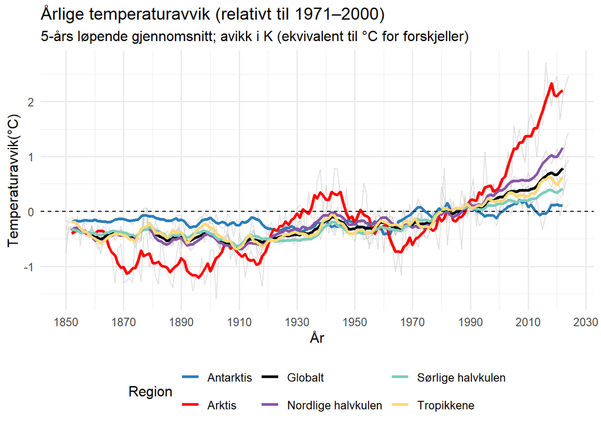

```r
library(ggplot2)

# Palette for regions
region_colors <- c(
  "Globalt" = "black",
  "Nordlige halvkulen" = "#8856a7",
  "Sørlige halvkulen" = "#7fcdbb",
  "Arktis" = "red",
  "Antarktis" = "#2c7fb8",
  "Tropikkene" = "#fed976"
)
# Mappe region-koder til fine labels
band_labels <- tribble(
  ~band,       ~label,
  "90S.90N",   "Globalt",
  "00N.90N",   "Nordlige halvkulen",
  "90S.00N",   "Sørlige halvkulen",
  "60N.90N",   "Arktis",
  "90S.60S",   "Antarktis",
  "20S.20N",   "Tropikkene"
)

plot_df <- annual %>% left_join(band_labels, by = "band")



# Graf
p <- ggplot(plot_df, aes(x = year)) +
  geom_line(aes(y = annual_anom_clim, group = band), color = "grey70", alpha = 0.4) +
  geom_line(aes(y = roll_n, color = label), size = 1.1, na.rm = TRUE) +
  geom_hline(yintercept = 0, linetype = "dashed", color = "black") +
  labs(
    title = "Årlige temperaturavvik (relativt til 1971–2000)",
    subtitle = paste0(smooth_yrs, "-års løpende gjennomsnitt; avikk i K (ekvivalent til °C for forskjeller)"),
    x = "År",
    y = "Temperaturavvik(°C)",
    color = "Region"
  ) +
  scale_x_continuous(breaks = seq(1850, 2030, by = 20)) +
  theme_minimal(base_size = 12) +
  theme(legend.position = "bottom")


my_colors <- c("black","#8856a7", "#7fcdbb", "red", "#2c7fb8", "#fed976")
names(my_colors) <- band_labels$label
p <- p + scale_color_manual(values = my_colors)


print(p)
```

- Hvordan skal vi tolke grafen - har utviklingen av temperaturen vært lik på ulike breddegrader på kloden?

Grafen viser at temperaturavviken er mer positive jo lengre nord vi kommer på kloden. Aller størst er avvikene for Arktis.

### Interaktiv plot

```r
library(dplyr)
library(ggplot2)
library(plotly)
library(htmlwidgets)

# Beregne sikkre begrensninger for 7 (5% buffer) (ikke sikkert at dette er strikt nødvendig)
ymin <- min(plot_df$annual_anom_clim, plot_df$roll_n, na.rm = TRUE)
ymax <- max(plot_df$annual_anom_clim, plot_df$roll_n, na.rm = TRUE)
pad <- 0.05 * (ymax - ymin + 1e-9)
ymin <- ymin - pad; ymax <- ymax + pad

# Bestem rekkefølgen for de ulike regionene
region_order <- c("60N.90N","00N.90N","20S.20N","90S.00N","90S.60S", "90S.90N")
plot_df <- plot_df %>%
 mutate(band = factor(band, levels = region_order))

# Lag en "desired label order" som tilsvarer region_order
desired_label_order <- band_labels$label[match(region_order, band_labels$band)]

plot_df <- plot_df %>%
  mutate(label = factor(label, levels = desired_label_order)) %>%
  # arrange so ggplot draws traces in the same order as the factor levels
  arrange(label, year)

# Bestem farger
my_colors <- c("red", "#8856a7", "#fed976", "#7fcdbb","#2c7fb8",  "black")
names(my_colors) <- desired_label_order

p <- ggplot(plot_df, aes(x = year)) +
  # background thin lines: group by label so each region becomes one trace
  geom_line(aes(y = annual_anom_clim, group = label),
            color = "grey70", alpha = 0.4) +
  # smoothed lines: group & color by label; put tooltip inside aes()
  geom_line(aes(y = roll_n, color = label, group = label,
                text = paste0(
                  "Region: ", label, "<br>",
                  "År: ", year, "<br>",
                  "Avvik: ", ifelse(is.na(roll_n), "NA",
                                             paste0(round(roll_n, 3), " °C"))
                )),
            size = 1.1, na.rm = TRUE) +
  geom_hline(yintercept = 0, linetype = "dashed") +
  labs(title = "Årlige temperaturavvik (relativt til 1971–2000)",
       subtitle = paste0(smooth_yrs, "-års løpende gjennomsnitt; avvik i K (ekvivalent til °C)"),
       x = "År", y = "Temperaturavvik (°C)", color = "Region") +
  scale_x_continuous(breaks = seq(1850, 2030, by = 20)) +
  theme_minimal(base_size = 12) +
  theme(legend.position = "bottom")



p <- p + scale_color_manual(values = my_colors)

# convert to plotly, use only the text tooltip, and set y axis range explicitly
gg_region <- ggplotly(p, tooltip = "text") %>%
  layout(hovermode = "x unified",
         #height = 16 * 250,
         yaxis = list(range = c(ymin, ymax))) %>%
  config(displayModeBar = TRUE)
```